# Is an Automatic or Manual Transmission better for MPG?

Moh A

03/03/2017

# Executive Summary

This project investigates the relationship between MPG (miles per gallon) and the type of transmission, which could be either Automatic or Manual. The project starts with exploratory analysis of the data set mtcars, which belong to 1974 Motor Trend US magazine. Then, statistical test and regression analysis were performed. T-test showed that Cars with manual transmission have around 7 MPG more than automatically transmitted cars. Then, after investigating several linear regression models, it was found that a model composed of ‘wt’(weight), ‘qsec’ (1/4 mile time), ‘am’(Transmission) and an interaction term of wt and am, achieved the highest adjusted R-squared value and can explain around 88% of the variance in MPG. Using the aforementioned model, car with manual transmission has 14.079 - 4.141*wt more MPG than automatic cars, given that weight (lb/1000) and qsec (1/4 mile time) are constant. For example, a car with manual transmission, weighing 1000 lbs, will have 9.938 more MPG than a car with automatic transmission.

# Exploratory Data Analyses

mtcars dataset is a data frame with 32 observations on 11 variables.

Firstly, reading the data and looking at the structure of the data set. The following numerical variables cyl, vs, am, gear and carb should be changed to a class of type facor, because they are actually categorical variabls and not continuous variable.

For readability purposes, the variables ‘am’ (Transmission Type) is changed into two levels: Automatic and Manual, instead of the default values 0 and 1. Also, the variable ‘vs’ (Engine type) is changed into two levels: V-engine and Straight-engine, instead of the default values 0 and 1.

Plotting the miles per galon versus the type of transimission (See Figure 1 in the Appendix), it is obvious that automatic transmission generally have lower mpg compared to manual. The median of mpg for automatic transmission is 17.3, while that for manual transmission is 22.8.

To get an idea about variables with a high correlation with mpg, a grid of plots was built and is shown in Figure 2 in the Appendix. As we can see, mpg vs am scored a correlation of only 0.6, while variables like cyl, disp, wt scored a correlation of over 0.8.

# Inference

Since the scope of this report is to explore the effect of the type of transmission on MPG. Our null hypothesis states that MPG data of manual transmission and automatic transmission are from the same population.

```
## [1] 0.001373638
```

```
## mean in group Automatic    mean in group Manual
##                17.14737                24.39231
```

We reject the null hypothesis, since the p.value is 0.00137. Therefore, automatic and manual transmission are from different populations.

# Model Selection and Analysis

## First model

Our first basic model is to fit all mtcars variables into the model:

```r
full_model <- lm(mpg~., mtcars)
```

Analysing this model, we find out that it has a residual standard error of 2.833 on 15 degrees of freedom. Its adjusted R-squared value is 0.779 which means that 77.9% of the variance in MPG can be explained by this model. A major downside with this model is that none of the coefficients are at 0.05 significance level.

## Second model

The model here is a simple model composed of only ‘am’ (transmission type) as a predicting variable for MPG. This is to explore whether transmission type only model can explain a lot of the variance in MPG

```r
am_model <- lm(mpg~am, mtcars)
```

Analysing this model, we find out that the residual standard error has risen to 4.902 on 30 degrees of freedom. Its adjusted R-squared value is 0.3385 which means that 33.85% of the variance in MPG can be explained by this model. However, the coefficients of this model are at 0.05 significance level.

The low adjusted R value indicates that transmission type on its own can not explain the variance in mpg.

## Third model

Using stepwise regression, which is a method of fitting regression models in which the choice of predictive variables is carried out by an automatic procedure. We use Backward elimination which involves starting with all candidate variables, testing the deletion of each variable using a chosen model fit criterion, deleting the variable (if any) whose loss gives the most statistically insignificant deterioration of the model fit, and repeating this process until no further variables can be deleted without a statistically significant loss of fit.

```r
stepwise_model <- step(full_model, direction = "backward", k=log(nrow(mtcars)), trace = FALSE)
```

Analysing this model, we find out that it is comprised of “mpg ~ wt + qsec + am”. Its residual standard error has fallen to 2.459 on 28 degrees of freedom. Its adjusted R-squared value is 0.8336 which means that 83.36% of the variance in MPG can be explained by this model. In addition, all the coefficients of this model are at 0.05 significance level.

## Fourth model

Building upon our third model which achieved a high adjusted R-squared value with all the coefficients at 0.05 significance level. It is noticeable to see a high correlation between ‘am’ and ‘wt’, which suggests improving our third model by adding an interaction term between these two variables. However, with ‘qsec’, it has a low correlation with both ‘am’ and ‘wt’.

```r
improved_stepwise_model <- lm(formula = mpg ~ wt + qsec + am + wt:am, data = mtcars)
```

| Model | Adj.r.squared | RSE |
| --- | --- | --- |
| Model 1 | 0.7790215 | 2.833169 |
| Model 2 | 0.3384589 | 4.902029 |
| Model 3 | 0.8335561 | 2.458846 |
| Model 4 | 0.8804219 | 2.084122 |

Model 4 (See “Model 4 Summary in the Appendix”) indicates that a car with manual transmission has 14.079 - 4.141*wt more MPG than automatic cars, given that weight (lb/1000) and qsec (1/4 mile time) are constant. For example, a car with manual transmission, weighing 1000 lbs, will have 9.938 more MPG than a car with automatic transmission.

# Residuals and Diagnostics

The residual plots are shown in Figure 3 in the Appendix, from these plots we can infer the following:

1. The Residuals vs. Fitted plot shows that points are randomy scattered, supporting the accuracy of the independence assumption.
2. The Normal Q‑Q plot indicates that the residuals are normally distributed because the points lie closely to the line.
3. The Scale‑Location plot confirms the constant variance assumption, as the points are randomly distributed.
4. The Residuals vs. Leverage shows that no outliers or influential points are present, because all cases are well inside of the Cook’s distance lines( red dashed 0.5 bands).

# Appendix

## Figure 1: MPG vs Type of Transmission

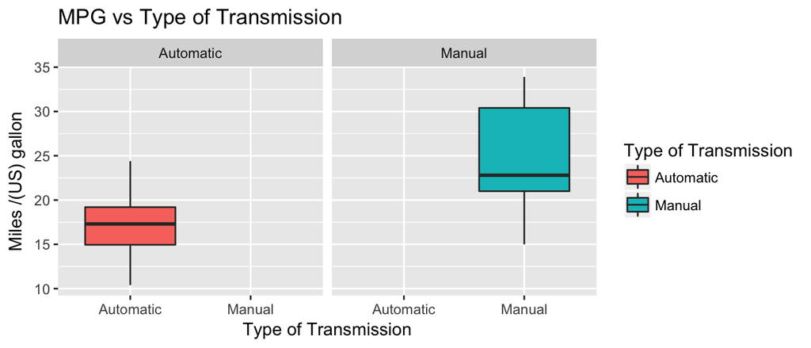

## Figure 2: Grid of pair plots of correlation between variables of ‘mtcars’

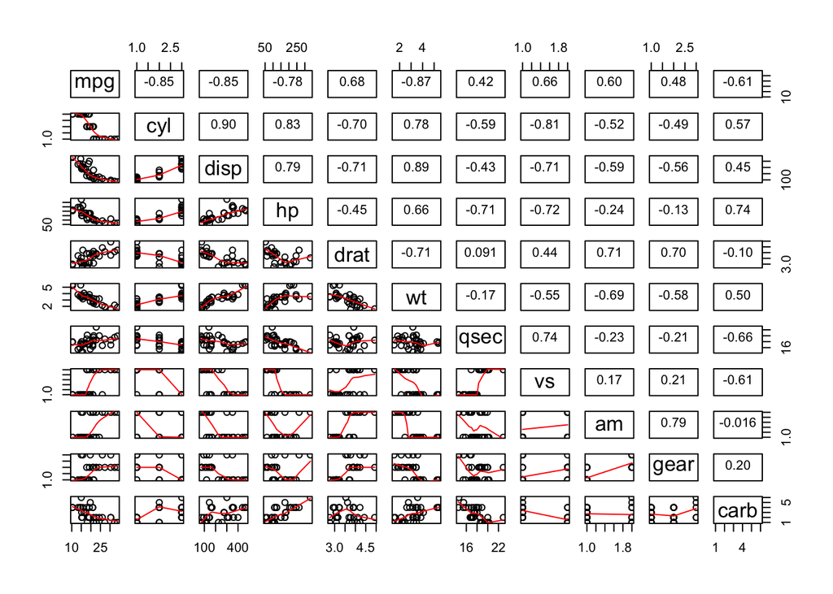

## Figure 3: Residual Plots

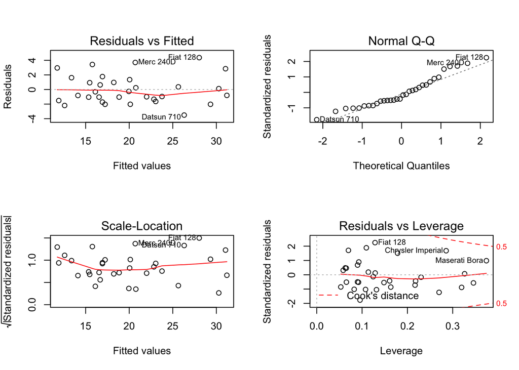

## Model 4 Summary

```
##
## Call:
## lm(formula = mpg ~ wt + qsec + am + wt:am, data = mtcars)
##
## Residuals:
##     Min      1Q  Median      3Q     Max
## -3.5076 -1.3801 -0.5588  1.0630  4.3684
##
## Coefficients:
##             Estimate Std. Error t value Pr(>|t|)
## (Intercept)    9.723      5.899   1.648 0.110893
## wt            -2.937      0.666  -4.409 0.000149 ***
## qsec           1.017      0.252   4.035 0.000403 ***
## amManual      14.079      3.435   4.099 0.000341 ***
## wt:amManual   -4.141      1.197  -3.460 0.001809 **
## ---
## Signif. codes:  0 '***' 0.001 '**' 0.01 '*' 0.05 '.' 0.1 ' ' 1
##
## Residual standard error: 2.084 on 27 degrees of freedom
## Multiple R-squared:  0.8959, Adjusted R-squared:  0.8804
## F-statistic: 58.06 on 4 and 27 DF,  p-value: 7.168e-13
```